# 2: Normalizing data

Ana BVA

23 September 2020

## Introduction

**Aim:** To normalize raw data

### Background

Some relevant information with links [GEO](https://www.ncbi.nlm.nih.gov/geo/)

## Input

This script needs the following files:

**Data:** Raw data (e.i. .CEL, .TXT)  
**2-Table_GSE-info.txt:** Table with GSE IDs and platform description

## Setup

For running the script, type:

```bash
ssh -X aaltamirano@dna.lavis.unam.mx
qrsh
cd /mnt/Genoma/amedina/aaltamirano/COPD/Meta-analysis_COPD/output_data/.out
 module load r/4.0.1

## OR
ssh ana@10.200.0.42
cd /home/ana/R-projects/Meta-analysis_COPD/output_data/.out

nohup R -e "rmarkdown::render(here::here('vignettes/2-normalizing-data.RMD'))" > output_data/.out/2-normalizing-data.out &
```

The script can be found in: /mnt/Genoma/amedina/amedinalab/DataDNA/R-projects/Meta-analysis_COPD/vignettes. And the directories were set using `R/setup.R` (e.i. DATA, OUPUT, DOWNLOAD) as a small functions that will paste the names into complete paths.

```r
knitr::opts_knit$set(root.dir = here::here())
source(here::here("R/setup.R"))
```

And this analysis is run in: /mnt/Genoma/amedina/amedinalab/DataDNA/R-projects/Meta-analysis_COPD

### Libraries

```r
library(limma)
library(oligo)
library(tidyverse)
```

## Functions

### **rawCEL_normCEL**: Pre-process raw data for Affymetrix

We first read and pre-process raw *.CEL* files. Each experiment has it own folder with raw data per sample. Then we normalized using RMA algorithm and finally, we save it.

In this function you need:

**Input:** GSE ID

**Output:**  
- Samples normalized  
- Boxplots  
- Histograms

```r
rawCEL_normCEL <- function(gse){

  # select and untar files
  gsepath <- file.path(here::here("GEOquery"),gse)
  print(gse)

  if(length(list.files(gsepath)) == 0){
    message("No Supplementary files found")
    } else if (length(list.files(gsepath)) < 3 & length(list.files(gsepath)) != 0 ){
    ifelse(any(list.files(gsepath,pattern="tar") !=0),
                untar(list.files(gsepath,full.names=T,pattern="tar"), exdir=gsepath),
                list.files(gsepath))
    } else{
    print(length(list.files(gsepath)))
    }

  # for CEL files "AFFYMETRIX"
  if(any(grepl("cel",list.files(gsepath),ignore.case = T))){
    message("This is an Affymetrix array")
    celfiles <- list.celfiles(gsepath,
                              full.names=TRUE,
                              listGzipped=TRUE)

    # read CEL files in R
    rawData <- read.celfiles(celfiles)
    #### Figures of raw data
    #pdf(str_c("raw_",gse,"_boxplot",TODAY,".pdf"))
    ## plots of raw data
    #boxplot(rawData,target="core")
    #hist(rawData,target="core")
    #dev.off()
    ## RMA normalization
    normData <- rma(rawData)
    #### Figures of Normalized data
    #pdf(str_c("norm_",gse,"_boxplot",TODAY,".pdf"))
    ## `plots of norm data
    boxplot(normData)
    hist(normData)
    # dev.off()
    #write.csv(exprs(normData),str_c("/normalized",gse,"_normData",TODAY,".tx  t"),quote=F)
    return(normData)
  }

  #for TXT files "AGILENT"
  else if(sum(grepl("txt",list.files(gsepath),ignore.case = T)) >2){
    message("This is an Agilent array")
    files <- list.files(gsepath,full.names=T, pattern = "txt")
    files <- grep("annot",files,value=T,invert=T)

     # read agilent files
    RG <- read.maimages(files,source = "agilent.median",green.only=T)
    #plots: raw data
    boxplot(RG$E)
    hist(RG$E)
    # normalizing data
    RG <- limma::backgroundCorrect(RG, method="normexp", offset=1)
    RG$E <- normalizeBetweenArrays(RG$E, method="quantile")
    RG$E <- log2(RG$E)
    #plots: norm
    boxplot(RG$E)
    hist(RG$E,100)

    return(RG)
  }

  # anyother case
  else{
    message("This is not Affymetrix or Agilent")
  }
}

#sapply(tissue,rawCEL_normCEL)
```

## Analysis

We had selected this experiments and downloaded raw data using srcripts:

- 0: Data selection `/0-Data-selection.RMD`
- 1: Dowload RAW data `/1-download_raw-data.RMD`

```r
gse_table <- read_tsv(DATA("2-Table_GSE-info.txt"))
knitr::kable(gse_table, caption = "GSE information")
```

GSE information

| Accession | No..Samples | GEO.SRA | COUNTRY | SUBMISSION_YEAR | PLATFORM | PLATFORM_ID |
| --- | --- | --- | --- | --- | --- | --- |
| GSE27597 | 72 | CEL | USA | 2011 | Affymetrix | GPL5175 |
| GSE106986 | 19 | TXT | Germany | 2017 | Agilent | GPL13497 |
| GSE37768 | 38 | CEL | Spain | 2012 | Affymetrix | GPL570 |
| GSE57148 | 189 | TXT | South Korea | 2014 | Illumina | GPL11154 |
| GSE47460 | 582 | TXT | USA | 2013 | Agilent | GPL14550 |
| GSE38974 | 59 | TXT | USA | 2012 | Agilent | GPL4133 |
| GSE8581 | 58 | CEL, CHP | USA | 2007 | Affymetrix | GPL570 |
| GSE1650 | 30 | CEL | USA | 2004 | Affymetrix | GPL96 |
| GSE1122 | 15 | CEL | USA | 2004 | Affymetrix | GPL80 |
| GSE119040 | 10 | NA | Argentina | 2018 | Affymetrix | GPL96 |
| GSE103174 | 53 | CEL, TXT | Spain | 2017 | Affymetrix | GPL13667 |
| GSE124180 | 63 | TSV | USA | 2018 | Illumina | GPL16791 |

### STEP 1: Normalizing raw data

Normalize raw data

```r
geo_norm <- sapply(gse_table$Accession[1:5],rawCEL_normCEL)
```

```
## [1] "GSE27597"
## [1] 70
```

```
## This is an Affymetrix array
```

```
## Platform design info loaded.
```

[output not shown]

[output cut: 12 more lines]

[output not shown]

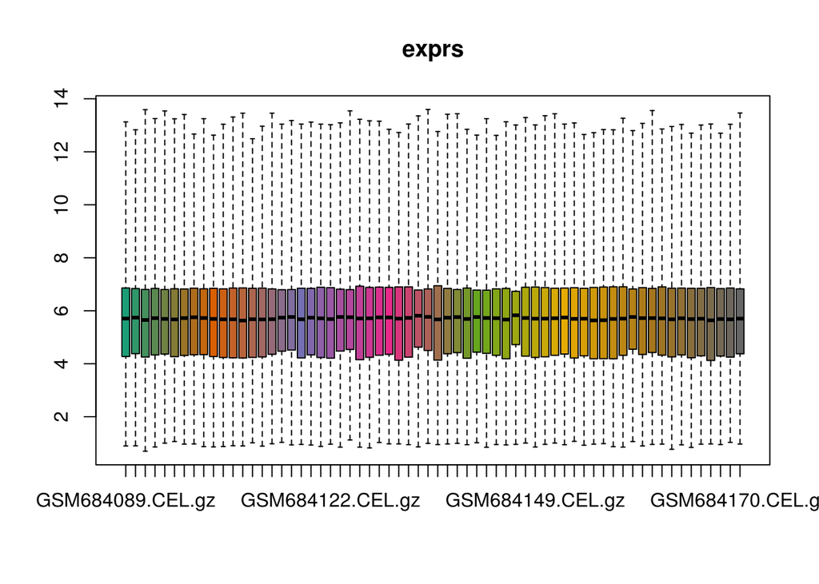

```
## [1] "GSE106986"
## [1] 21
```

```
## This is an Agilent array
```

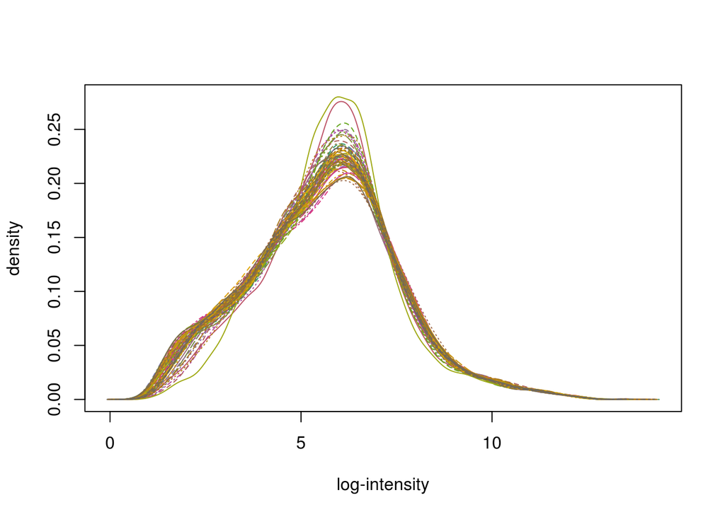

[output not shown]

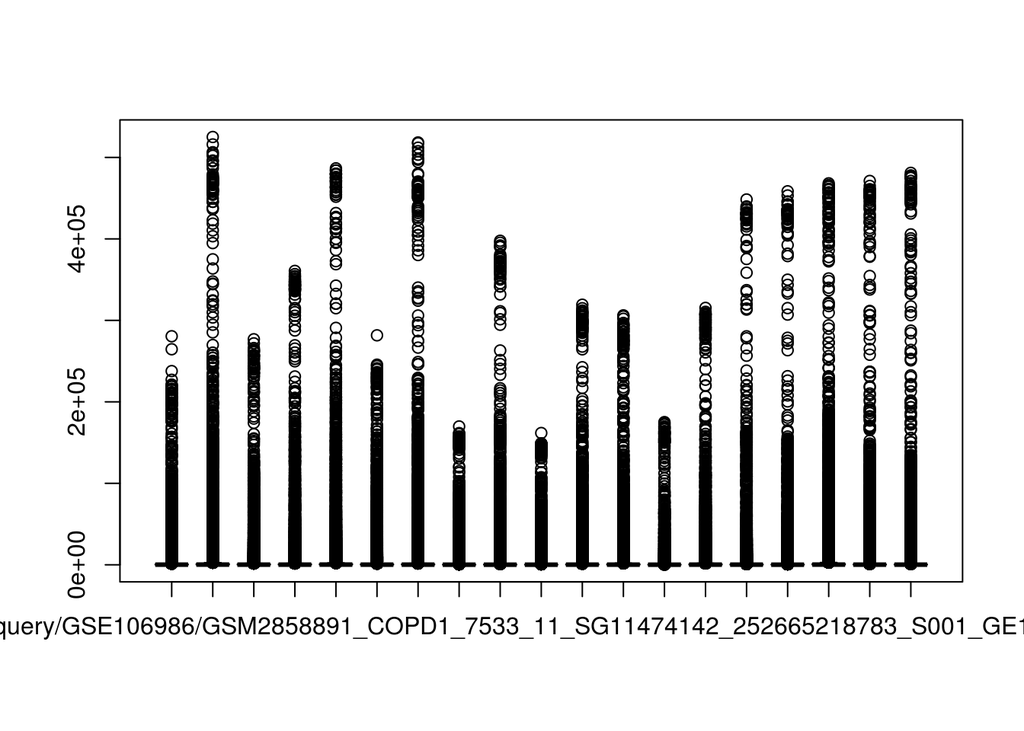

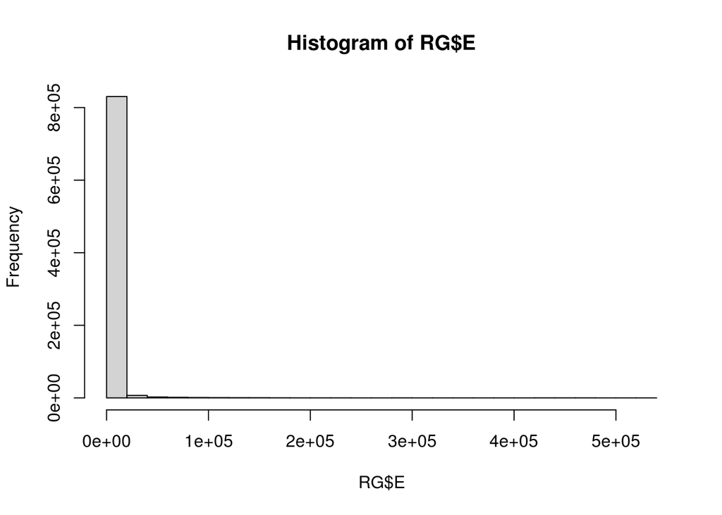

[output not shown]

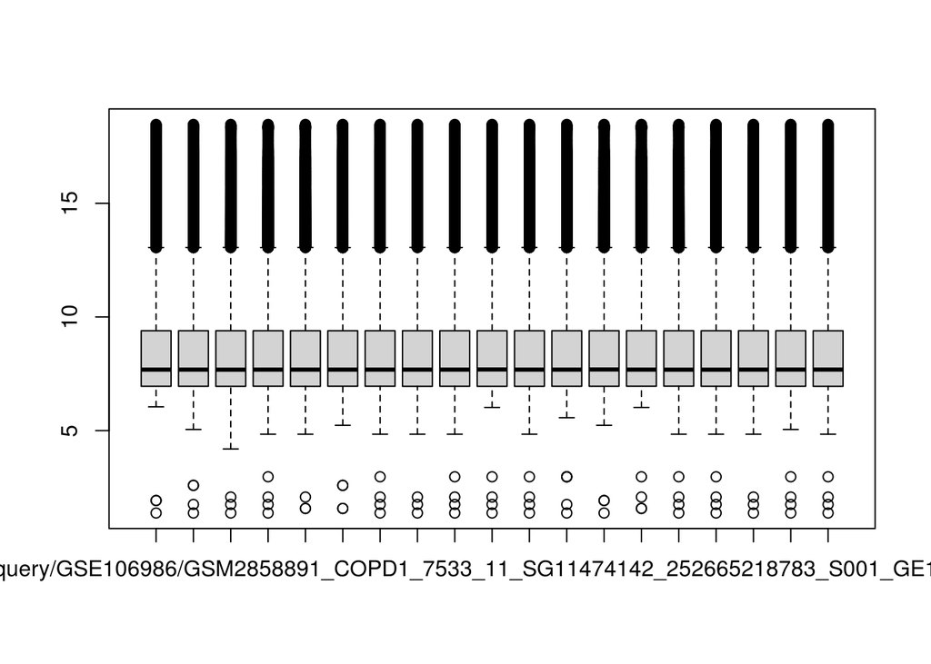

```
## [1] "GSE37768"
## [1] 39
```

```
## This is an Affymetrix array
```

```
## Platform design info loaded.
```

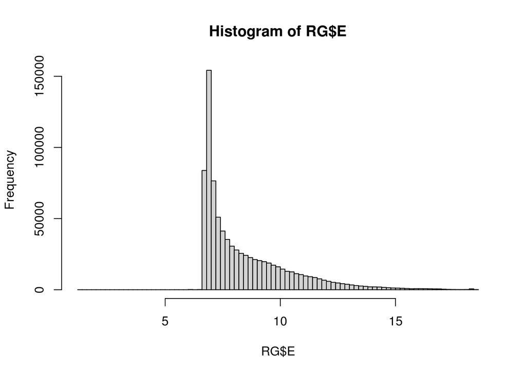

[output not shown]

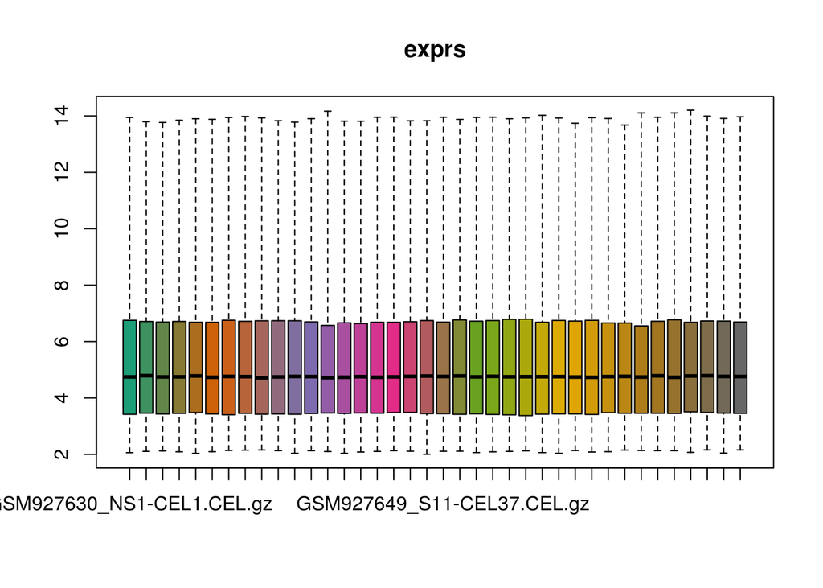

```
## [1] "GSE57148"
```

```
## This is not Affymetrix or Agilent
```

```
## [1] "GSE47460"
## [1] 431
```

```
## This is an Agilent array
```

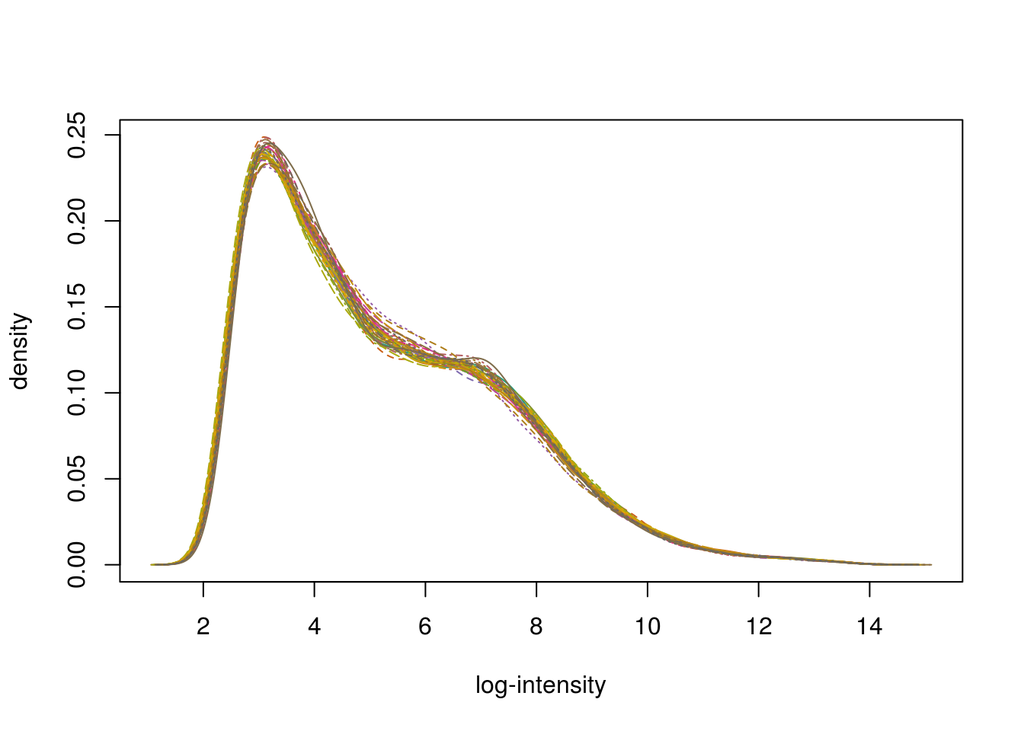

[output not shown]

[output cut: 374 more lines]

[output not shown]

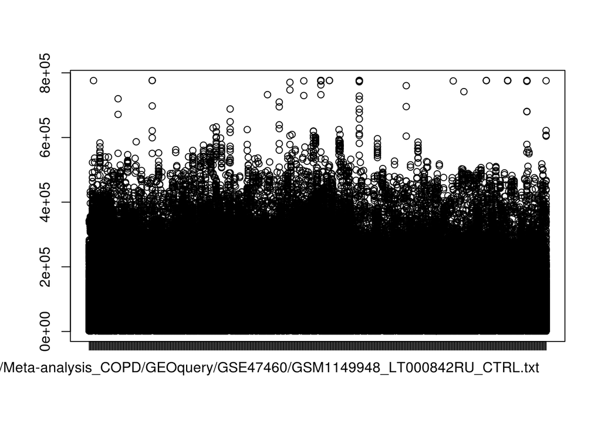

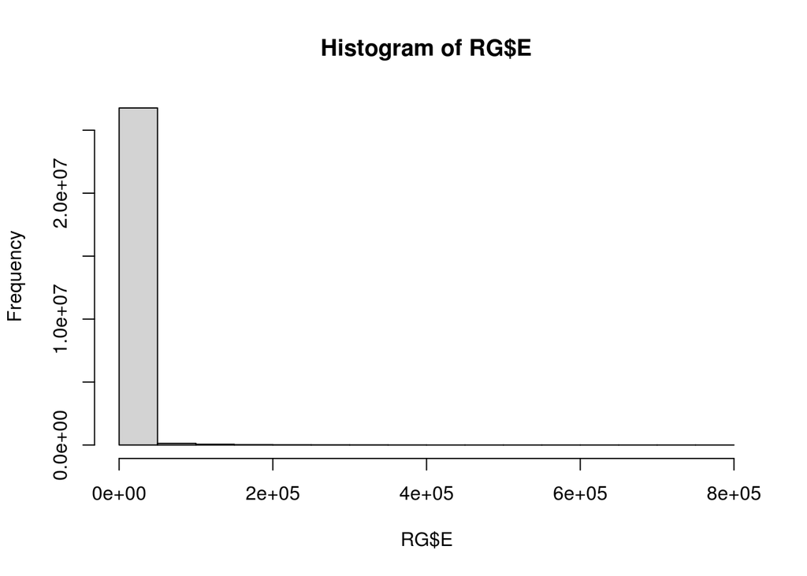

[output not shown]

[output cut: 374 more lines]

[output not shown]

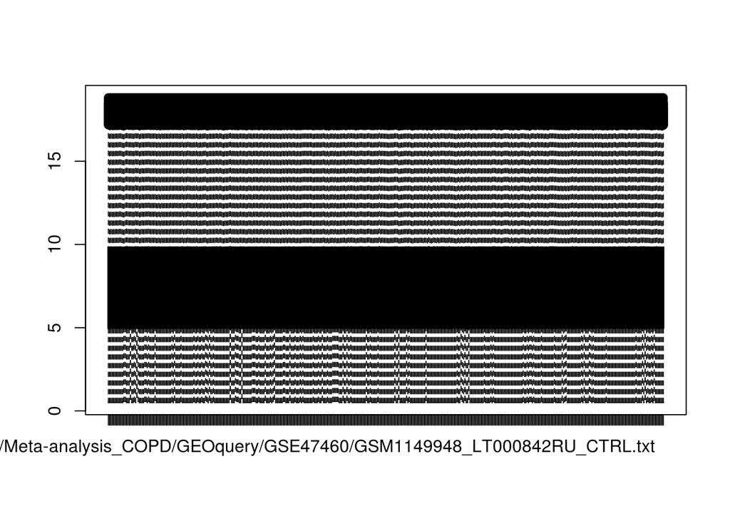

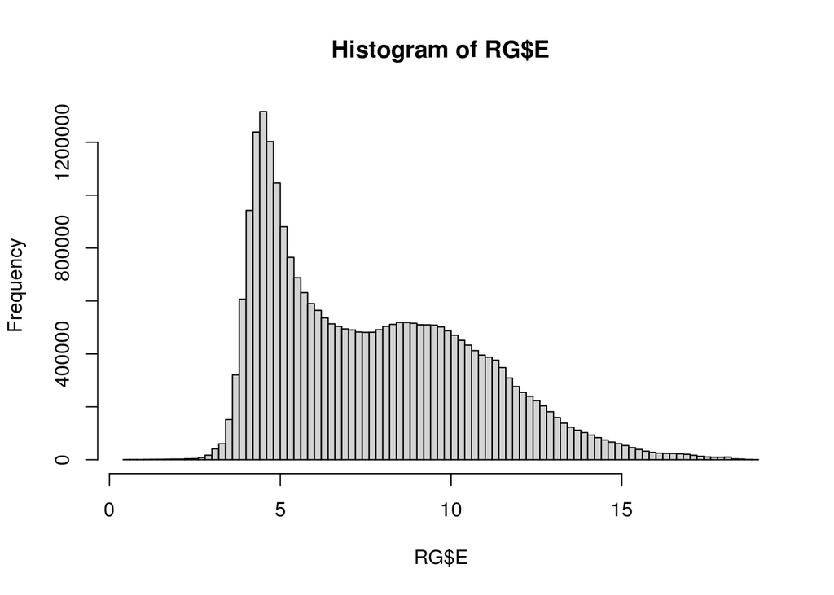

```r
saveRDS(geo_norm,OUTPUT(c(TODAY,"_normData.RDS")))
```